# Group_4

# Group 4

Anuoluwapo Akinkunmi, Christa Ingabire, Ceilidh Torrance

## Q1. Where did you live before MDS, and what is one thing you miss about it?

- **Christa**: I lived in Kigali, Rwanda and I miss my family
- **Ceilidh**: Before MDS I lived in Calgary. The thing I miss about Calgary is being close to my family.
- **Anuoluwapo**: Before MDS I lived in Abuja, Nigeria and I miss the food.

## Q2. What did you do before MDS: a degree, a job, or both?

- **Christa**: Before MDS, I graduated college with a computer science degree in 2023 and was most recently working as a data engineer
- **Ceilidh**: I graduated with my Bachelors in Computer Science in 2021. From 2021 until I started MDS I was working as a Marketing Software Consultant.
- **Anuoluwapo**: Before MDS I worked as a survey data manager.

## Q3. What is a skill you have that has nothing to do with data science?

- **Christa**: Film Photography
- **Ceilidh**: I can sew and crochet!
- **Anuoluwapo**: Another skill i have is Baking.

## Q4. What do you do when you are not in front of a computer?

- **Christa**: I’m trying out a new coffee shop or restaurant
- **Ceilidh**: I like to read, craft, watch TV, and spend time with friends and family.
- **Anuoluwapo**: I can either sleep, take a walk, cook or go play tennis.

## Anuoluwapo Akinkunmi (anu120)

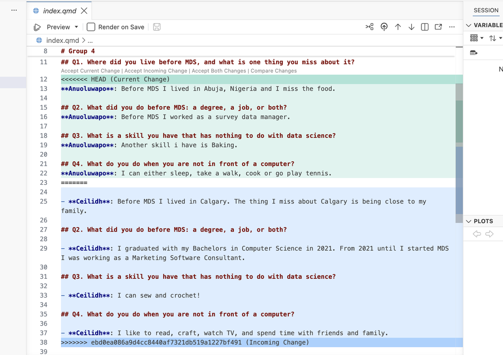

## Christa Ingabire (cingabir)

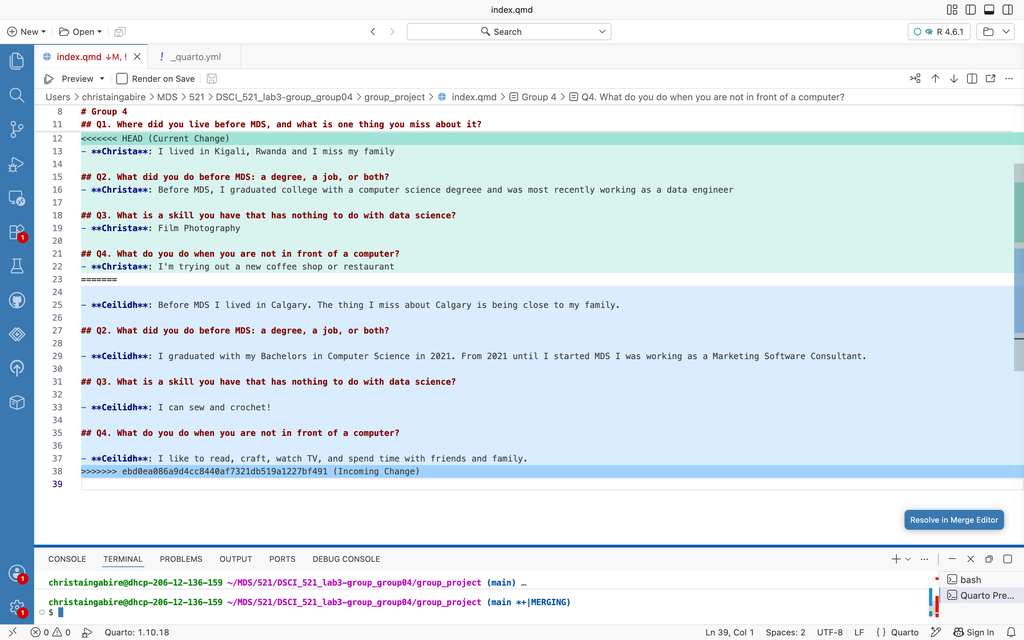

## Ceilidh Torrance (ceilidh2)

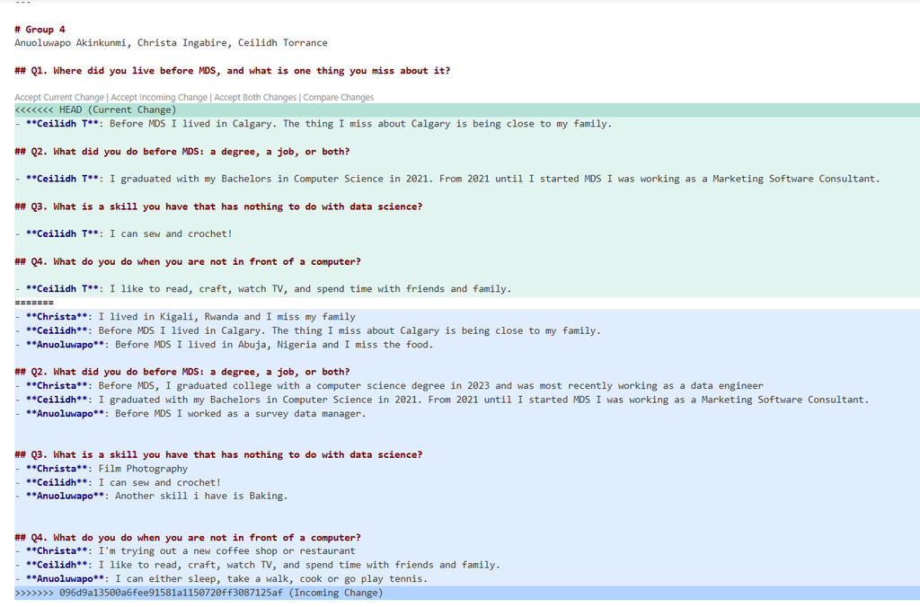